# Econ 4010 Homework 6

RyanYip

```
## Version 0.4-0 included new data defaults. See ?getSymbols.
```

```
## [1] "English_United States.1252"
```

[output not shown]

[output not shown]

```
## [1] 188
```

```
## [1] 188
```

## Question 1

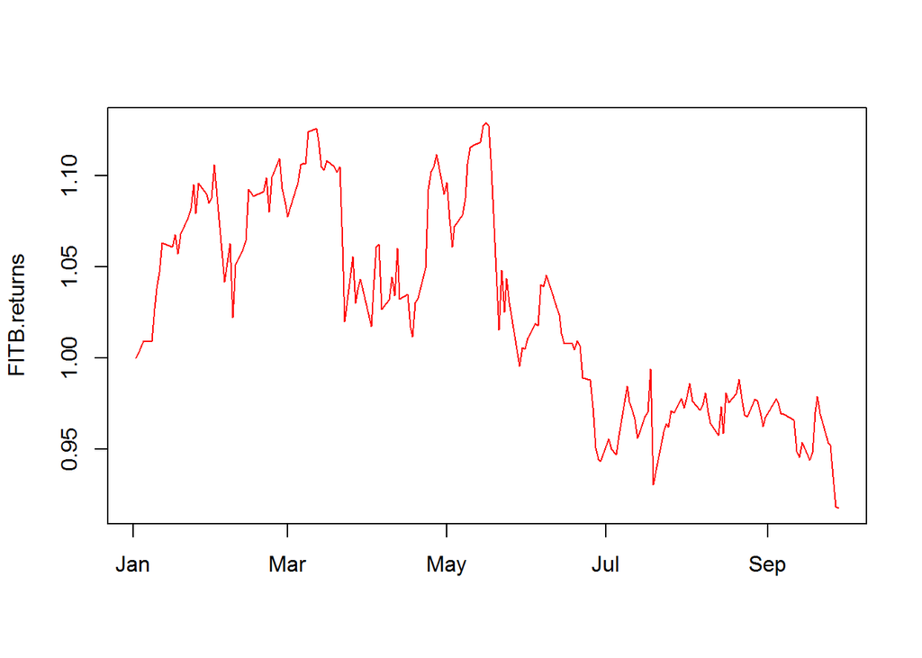

## Question 2

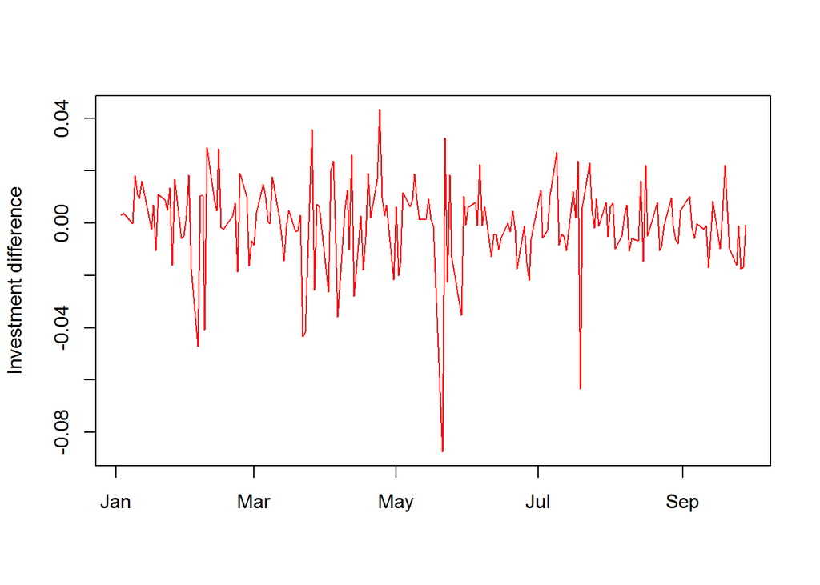

## Question 3

```
##     FITB.Open     FITB.High      FITB.Low    FITB.Close   FITB.Volume
##  1.836475e+00  1.878659e+00  1.811297e+00  1.723536e+00  2.709416e+06
## FITB.Adjusted
##  1.586929e+00
```

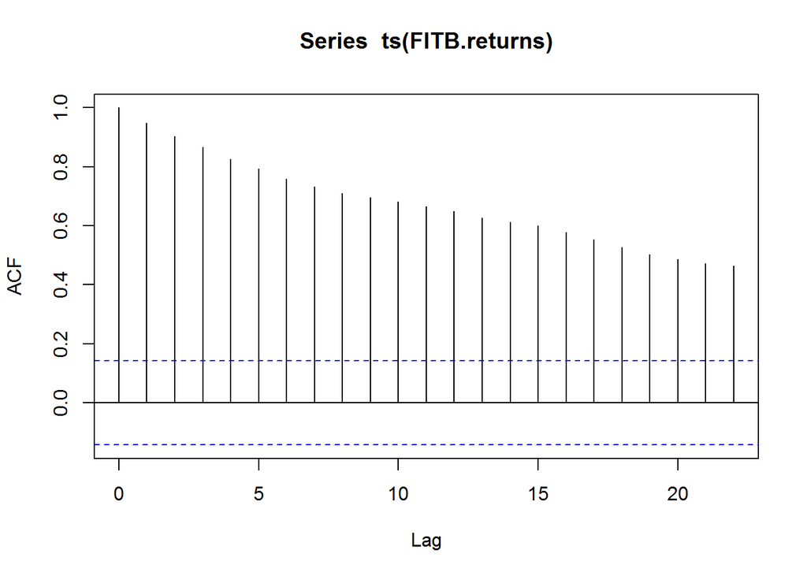

```
##
##  Phillips-Perron Unit Root Test
##
## data:  ts(FITB.returns)
## Dickey-Fuller Z(alpha) = -21.023, Truncation lag parameter = 4,
## p-value = 0.05039
## alternative hypothesis: stationary
```

According to the ACF plot,The above ACF is “decaying”, or decreasing, very slowly, and remains well above the significance range (dotted blue lines). This is indicative of a non-stationary series.And the ** Phillips–Perron Unit Root Test ** also tells us that ,the p-value of test is greater 0.05,which indicates that it is not significant.So,we can conclude that,this variable is not stationary.

## Question 4

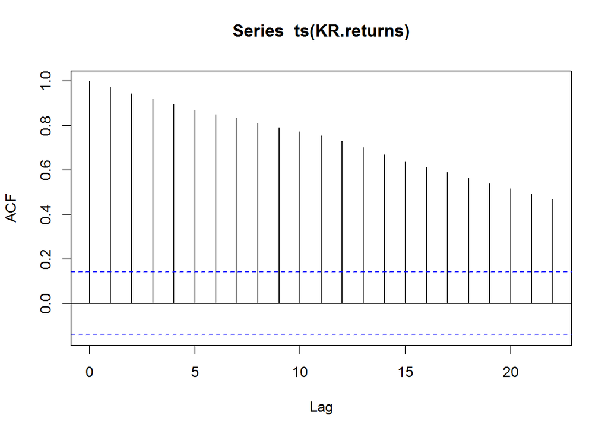

```
##
##  Phillips-Perron Unit Root Test
##
## data:  ts(KR.returns)
## Dickey-Fuller Z(alpha) = -6.4206, Truncation lag parameter = 4,
## p-value = 0.7476
## alternative hypothesis: stationary
```

According to the result got from above analysis,the analysis process and result is same as Question 3.So this variable is not stationary.

#### Plot the difference of KR returns

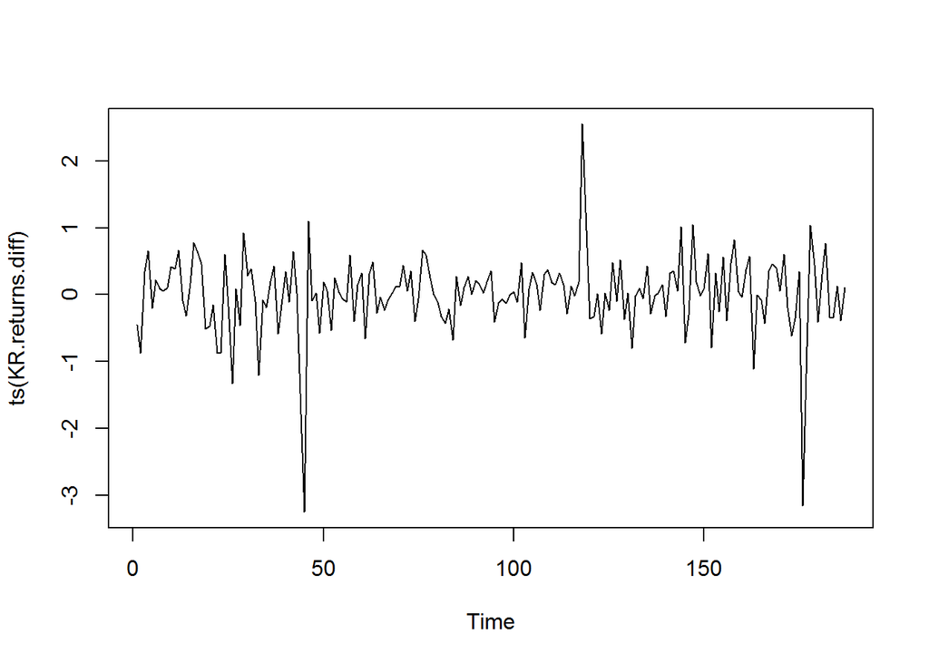

```
## [1] "pp test on difference of KR returns \n"
```

```
##
##  Phillips-Perron Unit Root Test
##
## data:  ts(KR.returns.diff)
## Dickey-Fuller Z(alpha) = -160.76, Truncation lag parameter = 4,
## p-value = 0.01
## alternative hypothesis: stationary
```

The plot and pp test shows that the difference of KR returns is stationary.

## Question 5

```
##
## Call:
## lm(formula = KR.diff ~ KR.lag_1 + KR.lag_2 + FITB.lag_1 + FITB.lag_2,
##     data = Data)
##
## Residuals:
##        Min         1Q     Median         3Q        Max
## -7.933e-17 -2.179e-17 -9.400e-18  8.050e-18  4.652e-16
##
## Coefficients: (2 not defined because of singularities)
##               Estimate Std. Error    t value Pr(>|t|)
## (Intercept)  2.740e-17  3.477e-18  7.880e+00 2.77e-13 ***
## KR.lag_1     1.000e+00  6.001e-18  1.666e+17  < 2e-16 ***
## KR.lag_2            NA         NA         NA       NA
## FITB.lag_1  -2.404e-16  2.153e-16 -1.117e+00    0.266
## FITB.lag_2          NA         NA         NA       NA
## ---
## Signif. codes:  0 '***' 0.001 '**' 0.01 '*' 0.05 '.' 0.1 ' ' 1
##
## Residual standard error: 4.753e-17 on 184 degrees of freedom
## Multiple R-squared:      1,  Adjusted R-squared:      1
## F-statistic: 1.44e+34 on 2 and 184 DF,  p-value: < 2.2e-16
```

## Question 6

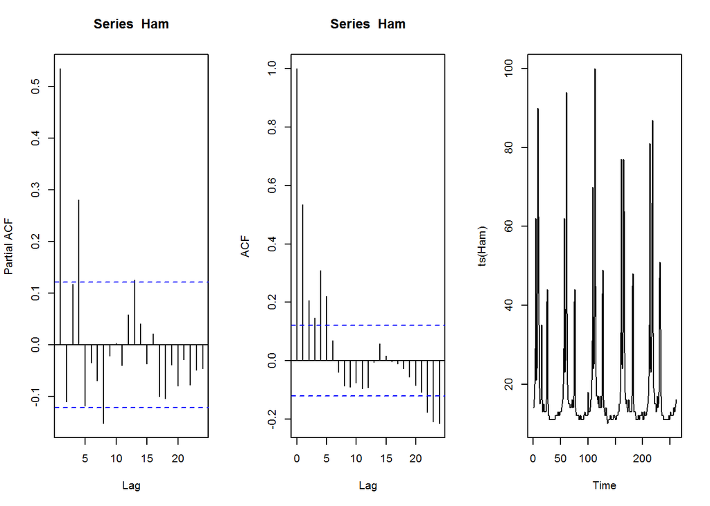

```
##
##  Augmented Dickey-Fuller Test
##
## data:  Ham
## Dickey-Fuller = -5.0358, Lag order = 6, p-value = 0.01
## alternative hypothesis: stationary
```

## Question 7

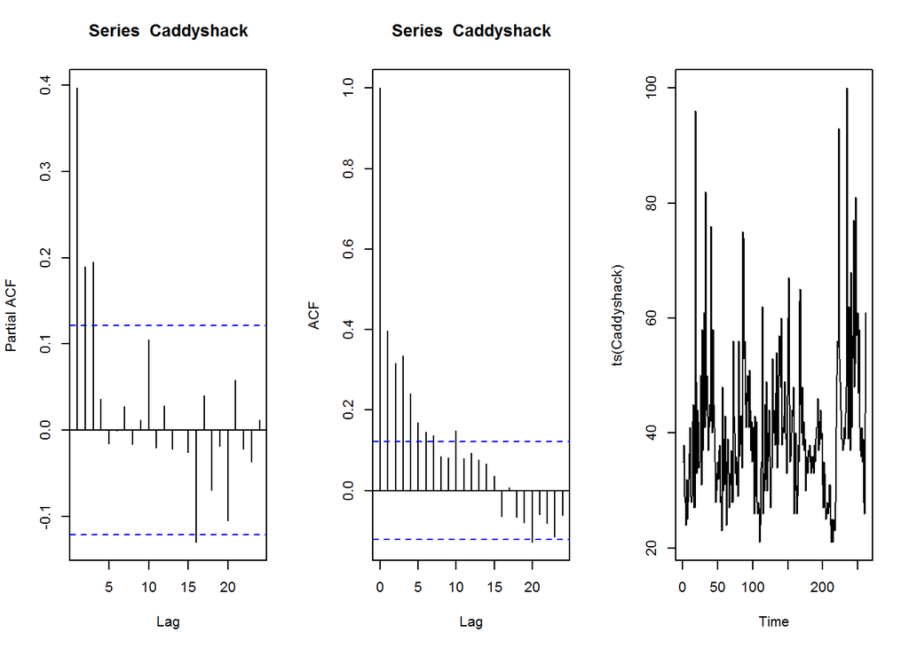

```
##
##  Augmented Dickey-Fuller Test
##
## data:  Caddyshack
## Dickey-Fuller = -4.3608, Lag order = 6, p-value = 0.01
## alternative hypothesis: stationary
```

The result is same as the question 6(Ham variable).And we get the same conclusion.So variable Caddyshack is stationary

## Question 8

### Fit Autoregressive Models on Caddyshack

```
##
## Call:
## ar(x = Caddyshack, aic = TRUE, order.max = 5)
##
## Coefficients:
##      1       2       3
## 0.2848  0.1266  0.1950
##
## Order selected 3  sigma^2 estimated as  129.7
```

According to the result above,the model best lag is 3

## Question 9

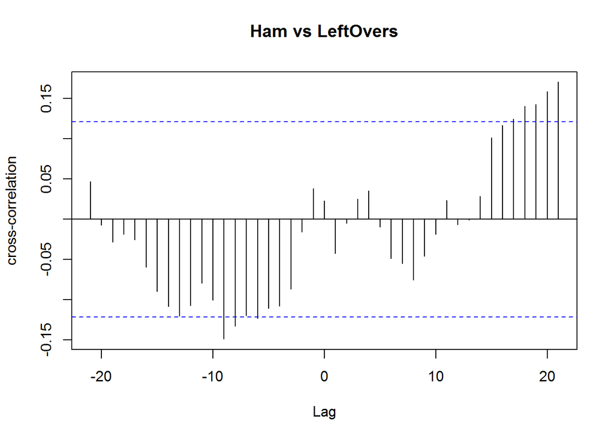

#### Run linear regression

Formula: c(Leftovers_lag_1,Leftovers_lag_2) ~ Ham_lag_1+Ham_lag_2+Ham_lag_3

```r
Data=data.frame(LeftOvers_lag_1=lag(LeftOvers,-1),
                LeftOvers_lag_2=lag(LeftOvers,-2),
                Ham_lag_1=lag(Ham,-1),
                Ham_lag_2=lag(Ham,-2),
                Ham_lag_3=lag(Ham,-3))
```

```
## Response LeftOvers_lag_1 :
##
## Call:
## lm(formula = LeftOvers_lag_1 ~ 0 + Ham_lag_1 + Ham_lag_2 + Ham_lag_3,
##     data = Data)
##
## Residuals:
##     Min      1Q  Median      3Q     Max
## -22.440  -0.385   0.929   3.929  96.555
##
## Coefficients: (2 not defined because of singularities)
##           Estimate Std. Error t value Pr(>|t|)
## Ham_lag_1  0.31319    0.03208   9.764   <2e-16 ***
## Ham_lag_2       NA         NA      NA       NA
## Ham_lag_3       NA         NA      NA       NA
## ---
## Signif. codes:  0 '***' 0.001 '**' 0.01 '*' 0.05 '.' 0.1 ' ' 1
##
## Residual standard error: 12.8 on 260 degrees of freedom
## Multiple R-squared:  0.2683, Adjusted R-squared:  0.2655
## F-statistic: 95.34 on 1 and 260 DF,  p-value: < 2.2e-16
##
##
## Response LeftOvers_lag_2 :
##
## Call:
## lm(formula = LeftOvers_lag_2 ~ 0 + Ham_lag_1 + Ham_lag_2 + Ham_lag_3,
##     data = Data)
##
## Residuals:
##     Min      1Q  Median      3Q     Max
## -22.440  -0.385   0.929   3.929  96.555
##
## Coefficients: (2 not defined because of singularities)
##           Estimate Std. Error t value Pr(>|t|)
## Ham_lag_1  0.31319    0.03208   9.764   <2e-16 ***
## Ham_lag_2       NA         NA      NA       NA
## Ham_lag_3       NA         NA      NA       NA
## ---
## Signif. codes:  0 '***' 0.001 '**' 0.01 '*' 0.05 '.' 0.1 ' ' 1
##
## Residual standard error: 12.8 on 260 degrees of freedom
## Multiple R-squared:  0.2683, Adjusted R-squared:  0.2655
## F-statistic: 95.34 on 1 and 260 DF,  p-value: < 2.2e-16
```

According to summary of the regression model, the coefficients of the Ham lag 1 is significant,which indicates that the lag 1 of Ham has strong correlation accross LeftOvers_lag_1 and LeftOvers_lag_2. So I have reason to believe searches for “Ham” affect the number of searches for “Leftovers”.

## Question 10

- H0: remove variable Ham from regression model with responce Leftovers
- H1: not remove variable Ham from regression model with responce Leftovers

#### stationary test

```r
adf.test(df$Ham)
```

```
##
##  Augmented Dickey-Fuller Test
##
## data:  df$Ham
## Dickey-Fuller = -5.0358, Lag order = 6, p-value = 0.01
## alternative hypothesis: stationary
```

According to the adf.test,Ham is stationary

#### Granger causality test

```
## Granger causality test
##
## Model 1: Leftovers ~ Lags(Leftovers, 1:3) + Lags(Ham, 1:3)
## Model 2: Leftovers ~ Lags(Leftovers, 1:3)
##   Res.Df Df      F Pr(>F)
## 1    251
## 2    254 -3 1.6726 0.1734
```

The p-value of the above result is 0.1734,which tells us that we can not reject the H0.According to the test,we can not conclude that whether this variable can use to be a predictor for Leftovers.